# 1. Descripció del dataset. Perquè és important i quina pregunta/problema pretén respondre?

El dataset original és el dataset de dades dels passatgers del TitÃ nic, que s’utilitza en la competició “Titanic: Machine Learning from Disaster”. Esta composat per dos fitxers, un de training (train.csv) amb 891 registres i un de test (test.csv) amb 418 registres. L’objectiu del dataset de la competició es generar un model de ML per predir la supervivència a l’enfonsament del vaixell, en base a la informació disponible dels passatgers.

El diccionari de dades del dataset original Ã©s :

| PassangerId | Identificador de passatger | Enter |  |  |
| --- | --- | --- | --- | --- |
| Survival | Identificador de supervivència | Factor | 0 = No, 1 = Yes |  |
| Pclass | Classe del passatge | Factor | 1 = 1a, 2 = 2ona, 3 = 3ª |  |
| Name | Nom del passatger | Text |  |  |
| Sex | Sexe | Factor | 1 = male, 2 = female |  |
| Age | Edat en anys | Nombre |  |  |
| Sibsp | Nombre de germans i dones embarcats | Enter |  |  |
| Parch | Nombre de pares i fills embarcats | Enter |  |  |
| Ticket | Nombre de Ticket | Text |  |  |
| Fare | Tarifa del passatge | Nombre |  |  |
| Cabin | Nombre de cabina | Text |  |  |
| Embarked | Port d’Embarcament | Factor | C = Cherbourg Q = Queenstown S = Southampton |  |

# 2. Integració i selecció de les dades d’interès a analitzar.

Es disposa de 2 fitxers, un fitxer d’entrenament (que disposa de les dades de supervivència) i un fitxer de test (sense les dades de supervivència). Es llegeixen les dades i s’integren en un únic dataset.

```r
library('dplyr')
dades <- bind_rows(read.csv('train.csv', stringsAsFactors = F), read.csv('test.csv', stringsAsFactors = F))
```

Es crea un dataset que integra els dos fitxers anomenat dades. La comanda dim(dades) mostra el nombre d’observacions i atributs de la mostra, que en aquest cas són 1309 observacions i 12 atributs. El camp **Survived** només estÃ informat per les entrades del fitxer d’entrenament (fins la posició 891). En la resta d’entrades, el valor en N.A.

```r
dim (dades)
```

```
## [1] 1309   12
```

La comanda str(dades) presenta de forma compacta lâ€™estructura interna del dataset.

```r
str(dades)
```

```
## 'data.frame':    1309 obs. of  12 variables:
##  $ PassengerId: int  1 2 3 4 5 6 7 8 9 10 ...
##  $ Survived   : int  0 1 1 1 0 0 0 0 1 1 ...
##  $ Pclass     : int  3 1 3 1 3 3 1 3 3 2 ...
##  $ Name       : chr  "Braund, Mr. Owen Harris" "Cumings, Mrs. John Bradley (Florence Briggs Thayer)" "Heikkinen, Miss. Laina" "Futrelle, Mrs. Jacques Heath (Lily May Peel)" ...
##  $ Sex        : chr  "male" "female" "female" "female" ...
##  $ Age        : num  22 38 26 35 35 NA 54 2 27 14 ...
##  $ SibSp      : int  1 1 0 1 0 0 0 3 0 1 ...
##  $ Parch      : int  0 0 0 0 0 0 0 1 2 0 ...
##  $ Ticket     : chr  "A/5 21171" "PC 17599" "STON/O2. 3101282" "113803" ...
##  $ Fare       : num  7.25 71.28 7.92 53.1 8.05 ...
##  $ Cabin      : chr  "" "C85" "" "C123" ...
##  $ Embarked   : chr  "S" "C" "S" "S" ...
```

```r
factors<-c('Sex','Embarked')
dades[factors] <- lapply(dades[factors], function(x) as.factor(x))
```

```r
str(dades)
```

```
## 'data.frame':    1309 obs. of  12 variables:
##  $ PassengerId: int  1 2 3 4 5 6 7 8 9 10 ...
##  $ Survived   : int  0 1 1 1 0 0 0 0 1 1 ...
##  $ Pclass     : int  3 1 3 1 3 3 1 3 3 2 ...
##  $ Name       : chr  "Braund, Mr. Owen Harris" "Cumings, Mrs. John Bradley (Florence Briggs Thayer)" "Heikkinen, Miss. Laina" "Futrelle, Mrs. Jacques Heath (Lily May Peel)" ...
##  $ Sex        : Factor w/ 2 levels "female","male": 2 1 1 1 2 2 2 2 1 1 ...
##  $ Age        : num  22 38 26 35 35 NA 54 2 27 14 ...
##  $ SibSp      : int  1 1 0 1 0 0 0 3 0 1 ...
##  $ Parch      : int  0 0 0 0 0 0 0 1 2 0 ...
##  $ Ticket     : chr  "A/5 21171" "PC 17599" "STON/O2. 3101282" "113803" ...
##  $ Fare       : num  7.25 71.28 7.92 53.1 8.05 ...
##  $ Cabin      : chr  "" "C85" "" "C123" ...
##  $ Embarked   : Factor w/ 4 levels "","C","Q","S": 4 2 4 4 4 3 4 4 4 2 ...
```

La comanda summary(dades) mostra una visió general dels atributs i en el cas de factors, es presenten els valors possibles i el nombre d’ocurrències per cada valor. A més, es pot observar que hi ha diversos valors mal informats o buits.

```r
summary (dades)
```

```
##   PassengerId      Survived          Pclass          Name
##  Min.   :   1   Min.   :0.0000   Min.   :1.000   Length:1309
##  1st Qu.: 328   1st Qu.:0.0000   1st Qu.:2.000   Class :character
##  Median : 655   Median :0.0000   Median :3.000   Mode  :character
##  Mean   : 655   Mean   :0.3838   Mean   :2.295
##  3rd Qu.: 982   3rd Qu.:1.0000   3rd Qu.:3.000
##  Max.   :1309   Max.   :1.0000   Max.   :3.000
##                 NA's   :418
##      Sex           Age            SibSp            Parch
##  female:466   Min.   : 0.17   Min.   :0.0000   Min.   :0.000
##  male  :843   1st Qu.:21.00   1st Qu.:0.0000   1st Qu.:0.000
##               Median :28.00   Median :0.0000   Median :0.000
##               Mean   :29.88   Mean   :0.4989   Mean   :0.385
##               3rd Qu.:39.00   3rd Qu.:1.0000   3rd Qu.:0.000
##               Max.   :80.00   Max.   :8.0000   Max.   :9.000
##               NA's   :263
##     Ticket               Fare            Cabin           Embarked
##  Length:1309        Min.   :  0.000   Length:1309         :  2
##  Class :character   1st Qu.:  7.896   Class :character   C:270
##  Mode  :character   Median : 14.454   Mode  :character   Q:123
##                     Mean   : 33.295                      S:914
##                     3rd Qu.: 31.275
##                     Max.   :512.329
##                     NA's   :1
```

# 3. Neteja de les dades.

## 3.1 Les dades contenen zeros o elements buits? Com gestionaries aquests casos?

Es pot observar que hi ha 418 valors no informats de Survived que corresponen als valors del fitxer de test, 263 registres no presents a **Age**, 1 registre que no informa el **Fare** i 2 registres que no indiquen el camp Embarked. Addicionalment hi ha diversos registres de **Fare** amb valor 0. Es procedeix a aplicar diverses tÃ¨cniques per completar aquestes dades.

- Per intentar determinar el valor de la tarifa (**Fare**) que manca, el primer que es fa Ã©s identificar el registre mal informat

```r
IdNoFare <- dades$PassengerId[is.na(dades$Fare)]
dades[IdNoFare,]
```

```
##      PassengerId Survived Pclass               Name  Sex  Age SibSp Parch
## 1044        1044       NA      3 Storey, Mr. Thomas male 60.5     0     0
##      Ticket Fare Cabin Embarked
## 1044   3701   NA              S
```

```r
dades$Fare[is.na(dades$Fare)] <- median(dades[dades$Pclass == '3' & dades$Embarked == 'S', ]$Fare, na.rm = TRUE)
dades[IdNoFare,]
```

```
##      PassengerId Survived Pclass               Name  Sex  Age SibSp Parch
## 1044        1044       NA      3 Storey, Mr. Thomas male 60.5     0     0
##      Ticket Fare Cabin Embarked
## 1044   3701 8.05              S
```

El valor assignat Ã©s 8,05 $

- Per intentar determinar el valor de l’Embarked que manca, el primer que es fa és identificar els registres mal informats

```r
IdNoEmbarked <- dades$PassengerId[dades$Embarked == '']
dades[IdNoEmbarked,]
```

```
##     PassengerId Survived Pclass                                      Name
## 62           62        1      1                       Icard, Miss. Amelie
## 830         830        1      1 Stone, Mrs. George Nelson (Martha Evelyn)
##        Sex Age SibSp Parch Ticket Fare Cabin Embarked
## 62  female  38     0     0 113572   80   B28
## 830 female  62     0     0 113572   80   B28
```

S’observa que es tracta de passatgers de classe 1 amb una tarifa de 80 $. Per determinar el port d’embarcament es calcula la tarifa mitjana per a la classe 1, per cada tipus d’embarcament possible.

```r
median(dades[dades$Pclass == '1' & dades$Embarked == 'S', ]$Fare, na.rm = TRUE)
```

```
## [1] 52
```

```r
median(dades[dades$Pclass == '1' & dades$Embarked == 'Q', ]$Fare, na.rm = TRUE)
```

```
## [1] 90
```

```r
median(dades[dades$Pclass == '1' & dades$Embarked == 'C', ]$Fare, na.rm = TRUE)
```

```
## [1] 76.7292
```

S’observa que la tarifa mitjana més propera a la dels registres no informats és 76,73 $ corresponent a l’embarcament ‘C’. S’assigna aquest valor als registres mal informats.

```r
dades$Embarked[c(IdNoEmbarked)] <- 'C'
```

- Donat que el nombre de valors **Age** no informats és elevat, la opció d’esborrar aquests valors suposaria la pèrdua de molts registres que si contenen altres valors i que és interessant conservar. Per aquest motiu, s’utilitzarÃ la llibreria mica (Multivariate Imputations by Chained Equations) que implementa un mètode per tractar valors no informats, creant múltiples imputacions per dades no informades multivariable. Cada variable incompleta es pot imputar per un model separat, permetent la imputació de barreges de dades de diversos tipus (categòriques, continues, binaries, …) i mantenir la coherència entre les imputacions mitjançant la implantació passiva.

S’aplica la funció mice a un subconjunt dels camps del dataset, no es contemplen els camps **PassengerId**, **Name**, **Ticket**, **Cabin**, **Survived** perquè no aporten res al model i es simplifiquen els cÃ lculs

```r
library('mice')
library('randomForest')
set.seed(1000)
dadesAge <- complete(mice(dades[, !names(dades) %in% c('PassengerId','Name', 'Ticket', 'Cabin', 'Survived')], method='rf'))
```

Mitjançant la comparació visual de plots sobre l’**Age** original i el estimat, es pot verificar que la assignació de les edats no informades no introdueix biaixos en les dades.

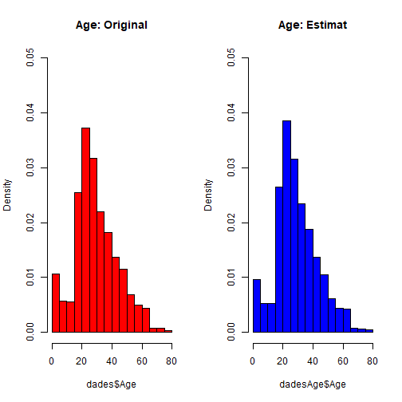

```r
par(mfrow=c(1,2))
hist(dades$Age, freq=F, main='Age: Original', col='red', ylim=c(0,0.05))
hist(dadesAge$Age, freq=F, main='Age: Estimat', col='blue', ylim=c(0,0.05))
```

```r
dades$Age <- dadesAge$Age
summary (dades)
```

```
##   PassengerId      Survived          Pclass          Name
##  Min.   :   1   Min.   :0.0000   Min.   :1.000   Length:1309
##  1st Qu.: 328   1st Qu.:0.0000   1st Qu.:2.000   Class :character
##  Median : 655   Median :0.0000   Median :3.000   Mode  :character
##  Mean   : 655   Mean   :0.3838   Mean   :2.295
##  3rd Qu.: 982   3rd Qu.:1.0000   3rd Qu.:3.000
##  Max.   :1309   Max.   :1.0000   Max.   :3.000
##                 NA's   :418
##      Sex           Age            SibSp            Parch
##  female:466   Min.   : 0.17   Min.   :0.0000   Min.   :0.000
##  male  :843   1st Qu.:21.00   1st Qu.:0.0000   1st Qu.:0.000
##               Median :28.00   Median :0.0000   Median :0.000
##               Mean   :29.74   Mean   :0.4989   Mean   :0.385
##               3rd Qu.:38.00   3rd Qu.:1.0000   3rd Qu.:0.000
##               Max.   :80.00   Max.   :8.0000   Max.   :9.000
##
##     Ticket               Fare            Cabin           Embarked
##  Length:1309        Min.   :  0.000   Length:1309         :  0
##  Class :character   1st Qu.:  7.896   Class :character   C:272
##  Mode  :character   Median : 14.454   Mode  :character   Q:123
##                     Mean   : 33.276                      S:914
##                     3rd Qu.: 31.275
##                     Max.   :512.329
##
```

- En el camp **Fare** s’observen diversos valors a 0 que es considera un valor fals, que correspon a valors no informats. Per estimar-los s’utilitza l’algoritme kNN. En primer lloc es substitueix els valors 0 per NA, ja que l’algoritme només estima els valors NA del dataset. A continuació s’aplica l’algoritme i s’obtenen valors pels valors no informats de **Fare**.

```r
# Els valors 0 de Fare es converteixen en NA i es dedueixen amb l'algoritme KNN
dades$Fare[dades$Fare == 0] <- NA

# Es Comprova si hi ha NA,s a Fare
sapply(dades, function(x) sum(is.na(x)))
```

```
## PassengerId    Survived      Pclass        Name         Sex         Age
##           0         418           0           0           0           0
##       SibSp       Parch      Ticket        Fare       Cabin    Embarked
##           0           0           0          17           0           0
```

Sâ€™observa que al **Fare** hi ha 17 registres no informats.

```r
library(VIM)

# S'aplica l'algoritme kNN
dades.kNN <- kNN(dades[, !names(dades) %in% c('PassengerId','Name', 'Ticket', 'Cabin', 'Survived')])

# Es comprova si hi ha NA,s a Fare estimat
sapply(dades.kNN, function(x) sum(is.na(x)))
```

```
##       Pclass          Sex          Age        SibSp        Parch
##            0            0            0            0            0
##         Fare     Embarked   Pclass_imp      Sex_imp      Age_imp
##            0            0            0            0            0
##    SibSp_imp    Parch_imp     Fare_imp Embarked_imp
##            0            0            0            0
```

```r
# Es comprova si hi ha zeros a Fare estimat
length(dades.kNN$Fare[dades.kNN$Fare == 0])
```

```
## [1] 0
```

```r
# S'assignen els valors de Fare estimats amb kNN al dataset original
dades$Fare = dades.kNN$Fare
```

- Per millorar el dataset es planteja la creaciÃ³ de nous camps a partir de les dades disponibles :

En primer lloc es crea el camp **TamanyFamilia** format a partir de la suma dels camps **SibSp** i **Parch** (cònjuges, germans, pares i fills) més el propi passatger.

```r
# CreaciÃ³ del camp TamanyFamilia
dades$TamanyFamilia <- dades$SibSp + dades$Parch + 1
```

A partir d'aquest camp es crea el camp **TipusFamilia**, de tipus factor, format a partir de rangs de nombre de membres de la famÃlia embarcats.

```r
# CreaciÃ³ del camp TipusFamilia
dades$TipusFamilia[dades$TamanyFamilia == 1] <- 'solitari'
dades$TipusFamilia[dades$TamanyFamilia < 5 & dades$TamanyFamilia > 1] <- 'petita'
dades$TipusFamilia[dades$TamanyFamilia > 4] <- 'nombrosa'
# ConversiÃ³ a factor
dades$TipusFamilia <- as.factor(dades$TipusFamilia)
```

TambÃ© a partir del camp Age es crea el camp **TipusEdat**, de tipus factor, format a partir de rangs d'edats.

```r
# Es crea el camp TipusEdat en funciÃ³ de franges d'edat i es converteix en factor
dades$TipusEdat[dades$Age < 18] <- 'Menor'
dades$TipusEdat[dades$Age >= 18 & dades$Age <= 65] <- 'Adult'
dades$TipusEdat[dades$Age > 65] <- 'AnciÃ¡ '
dades$TipusEdat <- as.factor(dades$TipusEdat)
```

En funció del tipus de metodologies i algoritmes a utilitzar es pot prioritzar l'ús d'atributs numèrics com en el cas d'**Age** o **TamanyFamilia**, o be, atributs de tipus factor com són **TipusEdat** o **TipusFamilia**, calculats a partir dels camps numèrics. També s'ha descartat l'ús del camp **Ticket** per que presenta una estructura bastant variable, no segueix un patró i correspon en gran part a codis de ticket autonumèrics que s'han considerats que aporten poca informació per a la questió plantejada. El camp **Cabin** també s'ha descartat perqué, si be era un camp que potencialment podria aportar informació rellevant respecte a la supervivència en funció de les cabines, per exemple, degut a la seva ubicació, el nombre de valors no informats és molt elevat (més de 4/5 parts) el que fa poc recomanble el completar els valors no informats mitjançant les tècniques aplicades en altres casos. Finalment s'ha utilitzar el camp TamanyFamilia, enlloc dels camps SibSp i Parch, ja que n'és l'agrupació d'ambos, reduint la dimensionalitat del dataset. S'han mantinut els camps **PassengerId** i **Name** per claredat ja que no aporten valor a la identificació de la supervivència.

Per tant el dataset final, integrat i filtrat és el següent :

```r
#dataset final integrat i filtrat
dades = dades[, !names(dades) %in% c('SibSp','Parch', 'Ticket', 'Cabin', 'TipusFamilia', "TipusEdat")]
summary (dades)
```

```
##   PassengerId      Survived          Pclass          Name
##  Min.   :   1   Min.   :0.0000   Min.   :1.000   Length:1309
##  1st Qu.: 328   1st Qu.:0.0000   1st Qu.:2.000   Class :character
##  Median : 655   Median :0.0000   Median :3.000   Mode  :character
##  Mean   : 655   Mean   :0.3838   Mean   :2.295
##  3rd Qu.: 982   3rd Qu.:1.0000   3rd Qu.:3.000
##  Max.   :1309   Max.   :1.0000   Max.   :3.000
##                 NA's   :418
##      Sex           Age             Fare         Embarked TamanyFamilia
##  female:466   Min.   : 0.17   Min.   :  3.171    :  0    Min.   : 1.000
##  male  :843   1st Qu.:21.00   1st Qu.:  7.925   C:272    1st Qu.: 1.000
##               Median :28.00   Median : 14.500   Q:123    Median : 1.000
##               Mean   :29.74   Mean   : 33.644   S:914    Mean   : 1.884
##               3rd Qu.:38.00   3rd Qu.: 31.387            3rd Qu.: 2.000
##               Max.   :80.00   Max.   :512.329            Max.   :11.000
##
```

El diccionari de dades del dataset final, integrat i filtrat és el següent :

| PassangerId | Identificador de passatger | Enter |  |  |
| --- | --- | --- | --- | --- |
| Survival | Identificador de supervivència | Factor | 0 = No, 1 = Yes |  |
| Pclass | Classe del passatge | Factor | 1 = 1a, 2 = 2ona, 3 = 3ª |  |
| Name | Nom del passatger | Text |  |  |
| Sex | Sexe | Factor | 1 = male, 2 = female |  |
| Age | Edat en anys | Nombre |  |  |
| Fare | Tarifa del passatge | Nombre |  |  |
| Embarked | Port d’Embarcament | Factor | C = Cherbourg Q = Queenstown S = Southampton |  |
| TamanyFamilia | Nombre de familiars embarcats | Enter |  |  |

## 3.2. IdentificaciÃ³ i tractament de valors extrems.

Identifiquem els valors extrems de les variables **Age** i **Fare** a partir de la funciÃ³ boxplot:

```r
outliers_age <- boxplot.stats(dades$Age)$out
outliers_fare <- boxplot.stats(dades$Fare)$out
outliers_age
```

```
##  [1] 66.0 65.0 65.0 71.0 70.5 70.0 65.0 64.0 65.0 71.0 64.0 80.0 70.0 70.0
## [15] 74.0 67.0 76.0 64.0 64.0 80.0 64.0
```

```r
outliers_fare
```

```
##   [1]  71.2833 263.0000 146.5208  82.1708  76.7292  80.0000  83.4750
##   [8]  73.5000 263.0000  77.2875 247.5208  73.5000  77.2875  79.2000
##  [15]  66.6000  69.5500  69.5500 146.5208  69.5500 113.2750  76.2917
##  [22]  90.0000  83.4750  90.0000  79.2000  86.5000 512.3292  79.6500
##  [29] 153.4625 135.6333  77.9583  78.8500  91.0792 151.5500 247.5208
##  [36] 151.5500 110.8833 108.9000  83.1583 262.3750 164.8667 134.5000
##  [43]  69.5500 135.6333 153.4625 133.6500  66.6000 134.5000 263.0000
##  [50]  75.2500  69.3000 135.6333  82.1708 211.5000 227.5250  73.5000
##  [57] 120.0000 113.2750  90.0000 120.0000 263.0000  81.8583  89.1042
##  [64]  91.0792  90.0000  78.2667 151.5500  86.5000 108.9000  93.5000
##  [71] 221.7792 106.4250  71.0000 106.4250 110.8833 227.5250  79.6500
##  [78] 110.8833  79.6500  79.2000  78.2667 153.4625  77.9583  69.3000
##  [85]  76.7292  73.5000 113.2750 133.6500  73.5000 512.3292  76.7292
##  [92] 211.3375 110.8833 227.5250 151.5500 227.5250 211.3375 512.3292
##  [99]  78.8500 262.3750  71.0000  86.5000 120.0000  77.9583 211.3375
## [106]  79.2000  69.5500 120.0000  93.5000  90.0000  80.0000  83.1583
## [113]  69.5500  89.1042 164.8667  69.5500  83.1583  82.2667 262.3750
## [120]  76.2917 263.0000 262.3750 262.3750 263.0000 211.5000 211.5000
## [127] 221.7792  78.8500 221.7792  75.2417 151.5500 262.3750  83.1583
## [134] 221.7792  83.1583  83.1583 247.5208  69.5500 134.5000 227.5250
## [141]  73.5000 164.8667 211.5000  71.2833  75.2500 106.4250 134.5000
## [148] 136.7792  75.2417 136.7792  82.2667  81.8583 151.5500  93.5000
## [155] 135.6333 146.5208 211.3375  79.2000  69.5500 512.3292  73.5000
## [162]  69.5500  69.5500 134.5000  81.8583 262.3750  93.5000  79.2000
## [169] 164.8667 211.5000  90.0000 108.9000
```

Si observem els valors extrems identificats de les variables **Age** i **Fare**, són valors coherents i que no tenen perqué suposar un error en la mostra de dades. No obstant, si volguesim eliminar els valors ho fariem mitjançant el codi següent:

```r
#dades<-dades[-which(dades$Age %in% outliers_age),]
#dades<-dades[-which(dades$Fare %in% outliers_fare),]
```

#4. AnÃ lisi de les dades.

##4.1. Selecció dels grups de dades que es volen analitzar/comparar (planificació dels anÃ lisis a aplicar).

##4.2. Comprovació de la normalitat i homogeneïtat de la variÃ ncia.

##4.3. Aplicació de proves estadístiques per comparar els grups de dades. En funció de les dades i de l’objectiu de l’estudi, aplicar proves de contrast d’hipòtesis, correlacions, regressions, etc. Aplicar almenys tres mètodes d’anÃ lisi diferents.

En l'apartat anterior, hem integrat els conjunts d'entrenament i test, aquest fet ens ha estat útil per a obtenir una major mostra per omplir amb major confiança els buits o zeros del conjunt. No obstant això, en aquest apartat ens centrarem en la variable **Survived**. Aquesta variable ens indica si un individuo va sobreviure o no a l'accident del titÃ nic, només la tenim informada per a les dades del conjunt d'entrenament, per tant, només utilitzarem les dades d'aquest.

```r
titanic_train <- dades[!is.na(dades$Survived),]
titanic_test <- dades[is.na(dades$Survived),]
```

### Hipòtesi nul·la i alternativa

En aquest cas d'estudi, prenem per a hipòtesi nul·la que la mitjana de les variables numèriques **Age, TamanyFamilia, Fare, Pclass** és independent a la variable **Survived**. És a dir, les mitjanes de les variables anteriors pels passatgers sobrevivents i les que no són iguals. \(H_0: \mu_1 = \mu_0\)

Com a hipòtesi alternativa, es té que la mitjana de cadascuna de les variables dels passatgers sobrevivents i la dels no sobrevivents és diferent. \(H_1: \mu_1 \not= \mu_0\)

On \(\mu_1\) és la mitjana de cadascuna de les variables numèriques pels passatgers supervivents i \(\mu_2\) és la mitjana de la variable d'estudi pels passatgers no supervivents.

### AssumpciÃ³ de normalitat

Comprovar si es compleix l'assumpció de normalitat en les dades. Per a fer-ho, s'aplica el test Shapiro-Wilk. Si el p-valor del test Shapiro Wilk és superior a 0.05, implica que la distribució de les dades no és significativament diferent de la distribució normal. És a dir, podem assumir normalitat.

```r
shapiro.test(titanic_train$Age)
```

```
##
##  Shapiro-Wilk normality test
##
## data:  titanic_train$Age
## W = 0.98099, p-value = 0.000000002263
```

```r
shapiro.test(titanic_train$TamanyFamilia)
```

```
##
##  Shapiro-Wilk normality test
##
## data:  titanic_train$TamanyFamilia
## W = 0.61508, p-value < 2.2e-16
```

```r
shapiro.test(titanic_train$Fare)
```

```
##
##  Shapiro-Wilk normality test
##
## data:  titanic_train$Fare
## W = 0.51848, p-value < 2.2e-16
```

```r
shapiro.test(titanic_train$Pclass)
```

```
##
##  Shapiro-Wilk normality test
##
## data:  titanic_train$Pclass
## W = 0.71833, p-value < 2.2e-16
```

```r
length(titanic_train$Pclass)
```

```
## [1] 891
```

Com que el p-valor és inferior a 0,05 en tots els casos, es rebutja la hipòtesi nul·la del test de Shapiro-Wilk que confirma l'assumpció de normalitat en les dades.

No obstant això, com que es té que \(N=891\) com a conseqüència del teorema del límit central, es pot considerar que les dades segueixen una distribució normal.

### HomogeneÃ¯tat de la variÃ ncia

Les variÃ ncies són desconegudes. A continuació, per a decidir si apliquem variÃ ncies iguals o diferents, apliquem el test de Fligner-Killena.

```r
library(car)

fligner.test(Age ~ Survived, data = titanic_train)
```

```
##
##  Fligner-Killeen test of homogeneity of variances
##
## data:  Age by Survived
## Fligner-Killeen:med chi-squared = 1.7343, df = 1, p-value = 0.1879
```

```r
fligner.test(TamanyFamilia ~ Survived, data = titanic_train)
```

```
##
##  Fligner-Killeen test of homogeneity of variances
##
## data:  TamanyFamilia by Survived
## Fligner-Killeen:med chi-squared = 19.647, df = 1, p-value =
## 0.000009317
```

```r
fligner.test(Fare ~ Survived, data = titanic_train)
```

```
##
##  Fligner-Killeen test of homogeneity of variances
##
## data:  Fare by Survived
## Fligner-Killeen:med chi-squared = 93.468, df = 1, p-value <
## 2.2e-16
```

```r
fligner.test(Pclass ~ Survived, data = titanic_train)
```

```
##
##  Fligner-Killeen test of homogeneity of variances
##
## data:  Pclass by Survived
## Fligner-Killeen:med chi-squared = 23.648, df = 1, p-value =
## 0.000001157
```

El p-valor és superior a 0,05 en la variable age i per tant en ella podem assumir la igualtat de variÃ ncies. No obstant això, per la resta de variables el p-valor és inferior a 0,05 i per tant s'assumeix la no igualtat de variÃ ncies.

Per tant, apliquem test t de dues mostres independents per a la diferència de mitjanes, variÃ ncies desconegudes i iguals en el cas de l'edat i apliquem test de wilcox en el cas de la mida de la família, la tarifa i la classe.

```r
t.test(Age ~ Survived,data = titanic_train, var.equal=TRUE)
```

```
##
##  Two Sample t-test
##
## data:  Age by Survived
## t = 1.5319, df = 889, p-value = 0.1259
## alternative hypothesis: true difference in means is not equal to 0
## 95 percent confidence interval:
##  -0.420076  3.408488
## sample estimates:
## mean in group 0 mean in group 1
##        30.38798        28.89377
```

```r
wilcox.test(TamanyFamilia ~ Survived,data = titanic_train, var.equal=TRUE)
```

```
##
##  Wilcoxon rank sum test with continuity correction
##
## data:  TamanyFamilia by Survived
## W = 77659, p-value = 0.0000007971
## alternative hypothesis: true location shift is not equal to 0
```

```r
wilcox.test(Fare ~ Survived,data = titanic_train, var.equal=TRUE)
```

```
##
##  Wilcoxon rank sum test with continuity correction
##
## data:  Fare by Survived
## W = 59732, p-value < 2.2e-16
## alternative hypothesis: true location shift is not equal to 0
```

```r
wilcox.test(Pclass ~ Survived,data = titanic_train, var.equal=TRUE)
```

```
##
##  Wilcoxon rank sum test with continuity correction
##
## data:  Pclass by Survived
## W = 127940, p-value < 2.2e-16
## alternative hypothesis: true location shift is not equal to 0
```

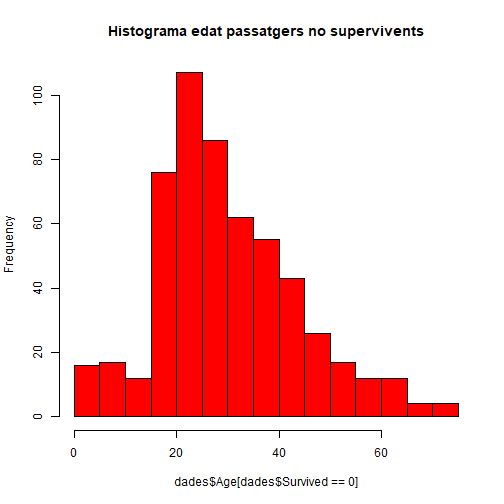

```r
hist(dades$Age[dades$Survived == 0], main = "Histograma edat passatgers no supervivents", col = "red")
```

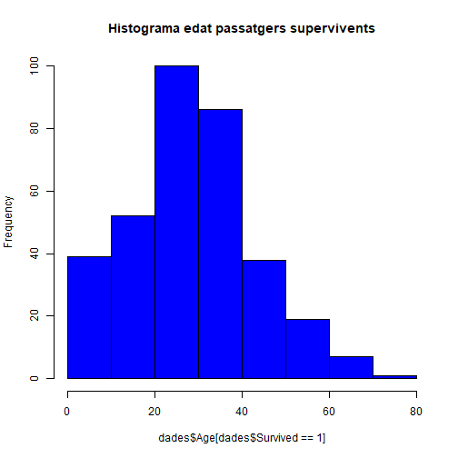

```r
hist(dades$Age[dades$Survived == 1], main = "Histograma edat passatgers supervivents", col = "blue")
```

### CorrelaciÃ³

Per a comprovar la correlació entre variables, tan sols comparem les variables numèriques. Per tant, per a aquesta prova seleccionem tan sols les variables **Age**, **TamanyFamilia**, **Fare** i **Pclass**. En primer lloc calculem la matriu de correlació entre les variables.

```r
titanic_cor <- data.frame(titanic_train$Age, titanic_train$TamanyFamilia, titanic_train$Fare, titanic_train$Pclass)
cor(titanic_cor)
```

```
##                             titanic_train.Age titanic_train.TamanyFamilia
## titanic_train.Age                   1.0000000                 -0.31425111
## titanic_train.TamanyFamilia        -0.3142511                  1.00000000
## titanic_train.Fare                  0.0875904                  0.21254320
## titanic_train.Pclass               -0.3543361                  0.06599691
##                             titanic_train.Fare titanic_train.Pclass
## titanic_train.Age                    0.0875904          -0.35433611
## titanic_train.TamanyFamilia          0.2125432           0.06599691
## titanic_train.Fare                   1.0000000          -0.55989875
## titanic_train.Pclass                -0.5598987           1.00000000
```

Estudiem doncs els casos amb major correlaciÃ³:

-Variables **Pclass** i **Fare**: correlació de -0.5598987. -Variables **Pclass** i **Age**: correlació de -0.3543361. -Variables **Age** i **TamanyFamilia**: correlació de -0.3142511.

Abans de comprovar la correlació entre els parells de variables anteriors, per a decidir quin és el mètode més adequat a aplicar, cal comprovar si es compleix l'assumpció de normalitat en les dades. Per a fer-ho, tal com hem fet anteriorment, s'aplica el test Shapiro-Wilk.

```r
shapiro.test(titanic_train$Pclass)
```

```
##
##  Shapiro-Wilk normality test
##
## data:  titanic_train$Pclass
## W = 0.71833, p-value < 2.2e-16
```

```r
shapiro.test(titanic_train$Age)
```

```
##
##  Shapiro-Wilk normality test
##
## data:  titanic_train$Age
## W = 0.98099, p-value = 0.000000002263
```

```r
shapiro.test(titanic_train$Fare)
```

```
##
##  Shapiro-Wilk normality test
##
## data:  titanic_train$Fare
## W = 0.51848, p-value < 2.2e-16
```

```r
shapiro.test(titanic_train$TamanyFamilia)
```

```
##
##  Shapiro-Wilk normality test
##
## data:  titanic_train$TamanyFamilia
## W = 0.61508, p-value < 2.2e-16
```

Com que en tots els casos, el p-valor és inferior a 0,05 es rebutja la hipòtesi nul·la del test de Shapiro-Wilk que confirma l'assumpció de normalitat en les dades. Per tant, per a estudiar la correlació entre els parells de variables estudiats aplicarem el test de Spearman.

```r
cor.test(titanic_train$Pclass,titanic_train$Fare, method="spearman")
```

```
##
##  Spearman's rank correlation rho
##
## data:  titanic_train$Pclass and titanic_train$Fare
## S = 203770000, p-value < 2.2e-16
## alternative hypothesis: true rho is not equal to 0
## sample estimates:
##        rho
## -0.7284641
```

```r
cor.test(titanic_train$Pclass,titanic_train$Age, method="spearman")
```

```
##
##  Spearman's rank correlation rho
##
## data:  titanic_train$Pclass and titanic_train$Age
## S = 158370000, p-value < 2.2e-16
## alternative hypothesis: true rho is not equal to 0
## sample estimates:
##        rho
## -0.3433576
```

```r
cor.test(titanic_train$TamanyFamilia,titanic_train$Age, method="spearman")
```

```
##
##  Spearman's rank correlation rho
##
## data:  titanic_train$TamanyFamilia and titanic_train$Age
## S = 145000000, p-value = 3.684e-12
## alternative hypothesis: true rho is not equal to 0
## sample estimates:
##        rho
## -0.2299892
```

En els tres casos, el p-valor és significatiu. Per tant, podem observar doncs una correlació prou significativa entre les parelles de variables estudiades, més concretament:

-Variables **Pclass** i **Fare**: correlació de -0.7284641 -Variables **Pclass** i **Age**: correlació de -0.3433576 -Variables **Age** i **TamanyFamilia**: correlació de -0.2299892

La primera resulta totalment comprensible ja que la tarifa sol anar marcada principalment per a la classe, on la primera és la que té tarifa més alta i la tercera la més baixa, és a dir correlació negativa.

El segon resultat també sembla coherent, ja que com més edat té una persona, normalment acostuma a tenir major poder adquisitiu i més comoditat busca, per tant, selecciona classes superiors.

Les variables **Age** i **TamanyFamilia** tenen una petita correlació negativa que també té una possible explicació, ja que per exemple els nens, no viatjaran sols. En canvi, els adults sí que podrien viatjar sols. Finalment, observem els diagrames de dispersió de les 3 parelles anteriors.

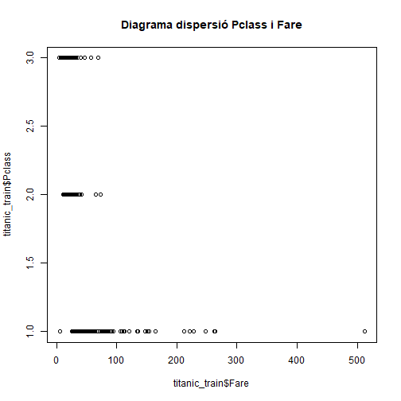

```r
plot(titanic_train$Fare, titanic_train$Pclass, main="Diagrama dispersiÃ³ Pclass i Fare")
```

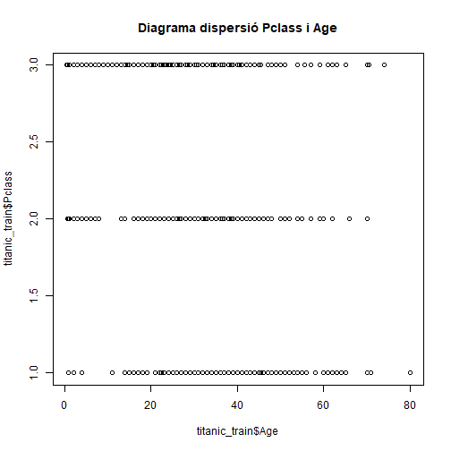

```r
plot(titanic_train$Age, titanic_train$Pclass, main="Diagrama dispersiÃ³ Pclass i Age")
```

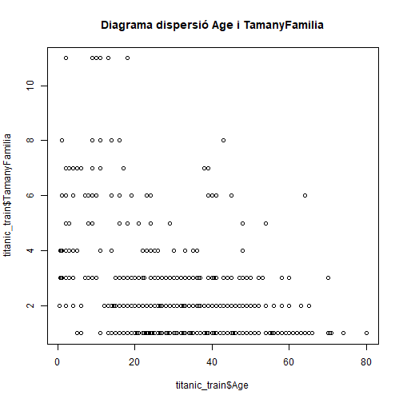

```r
plot(titanic_train$Age, titanic_train$TamanyFamilia, main="Diagrama dispersiÃ³ Age i TamanyFamilia")
```

En primer lloc cal tractar les variables categòriques. Usant el que s’anomena variables dummy podrem calcular el model lineal. Per a fer-ho, especificarem quina és la categoria de referència amb la funció relevel(). En la variable **Sex**, la categoria de referència és “female” i per a la variable **Embarked** la categoria de referència és “S”

```r
titanic_train$sexR <- relevel(titanic_train$Sex, ref = "female")
titanic_train$EmbarkedR <- relevel(titanic_train$Embarked, ref = "S")
```

```r
library('boot')
model1<- glm(Survived ~ sexR+TamanyFamilia+Age+EmbarkedR+Pclass,data=titanic_train)
cv.error1 = cv.glm(titanic_train,model1,K=10)$delta
summary(model1)
```

```
##
## Call:
## glm(formula = Survived ~ sexR + TamanyFamilia + Age + EmbarkedR +
##     Pclass, data = titanic_train)
##
## Deviance Residuals:
##      Min        1Q    Median        3Q       Max
## -1.00624  -0.21724  -0.07228   0.22000   0.98801
##
## Coefficients:
##                 Estimate Std. Error t value   Pr(>|t|)
## (Intercept)     1.323701   0.066827  19.808    < 2e-16 ***
## sexR[T.male]   -0.509715   0.027997 -18.206    < 2e-16 ***
## TamanyFamilia  -0.031486   0.008508  -3.701   0.000228 ***
## Age            -0.005025   0.001023  -4.910 0.00000109 ***
## EmbarkedR[T.C]  0.069263   0.033884   2.044   0.041235 *
## EmbarkedR[T.Q]  0.066257   0.047435   1.397   0.162831
## Pclass         -0.181467   0.017563 -10.332    < 2e-16 ***
## ---
## Signif. codes:  0 '***' 0.001 '**' 0.01 '*' 0.05 '.' 0.1 ' ' 1
##
## (Dispersion parameter for gaussian family taken to be 0.1446284)
##
##     Null deviance: 210.73  on 890  degrees of freedom
## Residual deviance: 127.85  on 884  degrees of freedom
## AIC: 814.69
##
## Number of Fisher Scoring iterations: 2
```

```r
cv.error1
```

```
## [1] 0.1463620 0.1462094
```

```r
model2<- glm(Survived ~ sexR+Age+Pclass,data=titanic_train)
cv.error2 = cv.glm(titanic_train,model2,K=10)$delta
summary(model2)
```

```
##
## Call:
## glm(formula = Survived ~ sexR + Age + Pclass, data = titanic_train)
##
## Deviance Residuals:
##      Min        1Q    Median        3Q       Max
## -1.05489  -0.23720  -0.07882   0.21561   0.97773
##
## Coefficients:
##                Estimate Std. Error t value  Pr(>|t|)
## (Intercept)   1.2454421  0.0571957  21.775   < 2e-16 ***
## sexR[T.male] -0.4994160  0.0275270 -18.143   < 2e-16 ***
## Age          -0.0038999  0.0009843  -3.962 0.0000803 ***
## Pclass       -0.1827548  0.0167452 -10.914   < 2e-16 ***
## ---
## Signif. codes:  0 '***' 0.001 '**' 0.01 '*' 0.05 '.' 0.1 ' ' 1
##
## (Dispersion parameter for gaussian family taken to be 0.1476099)
##
##     Null deviance: 210.73  on 890  degrees of freedom
## Residual deviance: 130.93  on 887  degrees of freedom
## AIC: 829.89
##
## Number of Fisher Scoring iterations: 2
```

```r
cv.error2
```

```
## [1] 0.1480090 0.1479531
```

```r
model3<- glm(Survived ~ sexR+EmbarkedR+Pclass,data=titanic_train)
cv.error3 = cv.glm(titanic_train,model3,K=10)$delta
summary(model3)
```

```
##
## Call:
## glm(formula = Survived ~ sexR + EmbarkedR + Pclass, data = titanic_train)
##
## Deviance Residuals:
##     Min       1Q   Median       3Q      Max
## -0.9774  -0.2303  -0.0772   0.2609   0.9228
##
## Coefficients:
##                Estimate Std. Error t value Pr(>|t|)
## (Intercept)     1.04527    0.04345  24.056   <2e-16 ***
## sexR[T.male]   -0.50886    0.02755 -18.469   <2e-16 ***
## EmbarkedR[T.C]  0.08515    0.03428   2.484   0.0132 *
## EmbarkedR[T.Q]  0.06059    0.04776   1.268   0.2050
## Pclass         -0.15307    0.01645  -9.307   <2e-16 ***
## ---
## Signif. codes:  0 '***' 0.001 '**' 0.01 '*' 0.05 '.' 0.1 ' ' 1
##
## (Dispersion parameter for gaussian family taken to be 0.1491811)
##
##     Null deviance: 210.73  on 890  degrees of freedom
## Residual deviance: 132.17  on 886  degrees of freedom
## AIC: 840.32
##
## Number of Fisher Scoring iterations: 2
```

```r
cv.error3
```

```
## [1] 0.1500152 0.1499269
```

```r
model4<- glm(Survived ~ sexR+TamanyFamilia+Pclass,data=titanic_train)
cv.error4 = cv.glm(titanic_train,model4,K=10)$delta
summary(model4)
```

```
##
## Call:
## glm(formula = Survived ~ sexR + TamanyFamilia + Pclass, data = titanic_train)
##
## Deviance Residuals:
##     Min       1Q   Median       3Q      Max
## -0.9495  -0.2526  -0.1091   0.2047   1.0192
##
## Coefficients:
##                Estimate Std. Error t value Pr(>|t|)
## (Intercept)    1.125021   0.043239  26.019  < 2e-16 ***
## sexR[T.male]  -0.532079   0.027951 -19.036  < 2e-16 ***
## TamanyFamilia -0.021392   0.008226  -2.600  0.00946 **
## Pclass        -0.154148   0.015688  -9.826  < 2e-16 ***
## ---
## Signif. codes:  0 '***' 0.001 '**' 0.01 '*' 0.05 '.' 0.1 ' ' 1
##
## (Dispersion parameter for gaussian family taken to be 0.1490855)
##
##     Null deviance: 210.73  on 890  degrees of freedom
## Residual deviance: 132.24  on 887  degrees of freedom
## AIC: 838.76
##
## Number of Fisher Scoring iterations: 2
```

```r
cv.error4
```

```
## [1] 0.1494668 0.1494115
```

```r
model5<- glm(Survived ~ sexR+Age,data=titanic_train)
cv.error5 = cv.glm(titanic_train,model5,K=10)$delta
summary(model5)
```

```
##
## Call:
## glm(formula = Survived ~ sexR + Age, data = titanic_train)
##
## Deviance Residuals:
##     Min       1Q   Median       3Q      Max
## -0.7450  -0.1894  -0.1879   0.2580   0.8142
##
## Coefficients:
##                Estimate Std. Error t value Pr(>|t|)
## (Intercept)   0.7391612  0.0356136  20.755   <2e-16 ***
## sexR[T.male] -0.5534355  0.0288230 -19.201   <2e-16 ***
## Age           0.0001031  0.0009723   0.106    0.916
## ---
## Signif. codes:  0 '***' 0.001 '**' 0.01 '*' 0.05 '.' 0.1 ' ' 1
##
## (Dispersion parameter for gaussian family taken to be 0.1672435)
##
##     Null deviance: 210.73  on 890  degrees of freedom
## Residual deviance: 148.51  on 888  degrees of freedom
## AIC: 940.16
##
## Number of Fisher Scoring iterations: 2
```

```r
cv.error5
```

```
## [1] 0.1677384 0.1676827
```

Dels models anteriors (i tots els provats) seleccionem el **model1**, ja que és el model que té major bondat per a tenir una menor AIC i també és el model amb un menor índex d'error entre els diferents conjunts de prova utilitzats en la validació creuada.

A partir d'aquest model predim la probabilitat de sobreviure de cadascÃºn dels registres del conjunt de test:

```r
titanic_test$sexR <- relevel(titanic_test$Sex, ref = "female")
titanic_test$EmbarkedR <- relevel(titanic_test$Embarked, ref = "S")

titanic_test$ProbSurvived <- predict(model1, titanic_test)
```

Mostrem la taula que contÃ© el resultat de les prediccions del conjunt de test:

```r
library(kableExtra)
kable(head(titanic_test), format = 'markdown')
```

|  | PassengerId | Survived | Pclass | Name | Sex | Age | Fare | Embarked | TamanyFamilia | sexR | EmbarkedR | ProbSurvived |
| --- | --- | --- | --- | --- | --- | --- | --- | --- | --- | --- | --- | --- |
| 892 | 892 | NA | 3 | Kelly, Mr. James | male | 34.5 | 7.8292 | Q | 1 | male | Q | 0.1310039 |
| 893 | 893 | NA | 3 | Wilkes, Mrs. James (Ellen Needs) | female | 47.0 | 7.0000 | S | 2 | female | S | 0.4801679 |
| 894 | 894 | NA | 2 | Myles, Mr. Thomas Francis | male | 62.0 | 9.6875 | Q | 1 | male | Q | 0.1742924 |
| 895 | 895 | NA | 3 | Wirz, Mr. Albert | male | 27.0 | 8.6625 | S | 1 | male | S | 0.1024324 |
| 896 | 896 | NA | 3 | Hirvonen, Mrs. Alexander (Helga E Lindqvist) | female | 22.0 | 12.2875 | S | 3 | female | S | 0.5742986 |
| 897 | 897 | NA | 3 | Svensson, Mr. Johan Cervin | male | 14.0 | 9.2250 | S | 1 | male | S | 0.1677532 |

# 5. RepresentaciÃ³ dels resultats a partir de taules i grÃ fiques.

Al llarg d'aquesta prÃ ctica s'han mostrat diferents grÃ fiques o taules per a mostrar els resultats. Com que una de les conclusions de l'accident del titÃ nic coneguda històricament és que les dones van obtenir un major índex de supervivència, afegim un grÃ fic que ens mostra la comparativa de la supervivència en funció del sexe.

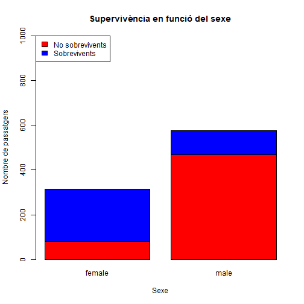

```r
counts = table(titanic_train$Survived, titanic_train$Sex)
barplot(counts, ylim=c(0, 1000), xlab="Sexe",ylab="Nombre de passatgers",main="SupervivÃ¨ncia en funciÃ³ del sexe",col = c("red", "blue"))
legend("topleft", fill=c("red", "blue"), legend=c("No sobrevivents", "Sobrevivents"))
```

# 6. Resolució del problema. A partir dels resultats obtinguts, quines són les conclusions? Els resultats permeten respondre al problema?

## 6.1.- Procés de neteja i validació

Es partia de dos conjunts de dades relatives als passatgers del Titanic. Un conjunt de training (on s’informava el camp Survived) i un conjunt de test (on no s’informava el camp Survived). El dataset s’utilitza per generar models de predicció de la probabilitat de supervivència en funció de les característiques del passatger. Per a la fase de neteja i validació de les dades s’ha optat per integrar els dos fitxers per disposar de més registres que permetessin aplicar tècniques per completar camps no informats amb major precisió. D’una anÃ lisi preliminar s’ha comprovat que el conjunt de dades presentava nombrosos camps no informats (en especial el camp Age). S’ha procedit a analitzar aquests camps i aplicar diverses tècniques per completar-los.

Per al camp Embarket (Origen d’embarcament) , s’han obtingut els registres no informats i s’observa que tots ells comparteixen tarifa i classe. S’ha obtingut la mitjana de la tarifa pels passatgers de classe 1 per cada port d’origen i s’ha assignat el port origen que tenia una tarifa mitjana més propera.

En el cas del camp Age, donat que hi havia molts camps no informats i era important conservar-los, sâ€™ha optat per aplicar la metodologia Mice (Multivariate Imputations by Chained Equations).

Finalment pel camp Fare, s’han substituït els valors 0 per valors no informats (per requeriment de l’algoritme kNN) i s’ha utilitzat l’algoritme kNN per estimar-los.

S’han creat camps nous com TamanyFamilia que és la agrupació dels camps SibSp i Parch, el que ha permès reduir la dimensió del dataset i s’han generat els camps factor TipusFamilia i TipusEdat per si eren interessants per l’aplicació de certs mètodes.

El dataset final esta format pels camps PassangerId, Survival, Pclass, Name, Sex , Age, Fare, Embarked i TamanyFamilia.

## 6.2.- AnÃ lisi de dades

Aplicant un test de correlació, hem detectat correlació negativa entre el preu del bitllet i la classe que es viatja, l'edat del passatger i la classe en la qual viatge o bé l'edat del passatger i el nombre de familiars a bord.

| Investigació prèvia | PC CR |
| --- | --- |
| Redacció de les respostes | PC CR |
| Desenvolupament codi | PC CR |